# Week 1 – Simple Linear Regression with mtcars Dataset

Miguel Garcia

2026-01-28

## Objective

The goal of this analysis is to model **miles per gallon (mpg)** as a function of **vehicle weight (wt)** using simple linear regression, and to interpret the statistical meaning of the results.

## Data Exploration

We begin by loading the built-in `mtcars` dataset and inspecting its structure.

```r
data(mtcars)
head(mtcars)
```

```
##                    mpg cyl disp  hp drat    wt  qsec vs am gear carb
## Mazda RX4         21.0   6  160 110 3.90 2.620 16.46  0  1    4    4
## Mazda RX4 Wag     21.0   6  160 110 3.90 2.875 17.02  0  1    4    4
## Datsun 710        22.8   4  108  93 3.85 2.320 18.61  1  1    4    1
## Hornet 4 Drive    21.4   6  258 110 3.08 3.215 19.44  1  0    3    1
## Hornet Sportabout 18.7   8  360 175 3.15 3.440 17.02  0  0    3    2
## Valiant           18.1   6  225 105 2.76 3.460 20.22  1  0    3    1
```

To understand the distribution of each variable, we examine summary statistics.

```r
summary(mtcars)
```

```
##       mpg             cyl             disp             hp             drat             wt             qsec             vs               am              gear            carb
##  Min.   :10.40   Min.   :4.000   Min.   : 71.1   Min.   : 52.0   Min.   :2.760   Min.   :1.513   Min.   :14.50   Min.   :0.0000   Min.   :0.0000   Min.   :3.000   Min.   :1.000
##  1st Qu.:15.43   1st Qu.:4.000   1st Qu.:120.8   1st Qu.: 96.5   1st Qu.:3.080   1st Qu.:2.581   1st Qu.:16.89   1st Qu.:0.0000   1st Qu.:0.0000   1st Qu.:3.000   1st Qu.:2.000
##  Median :19.20   Median :6.000   Median :196.3   Median :123.0   Median :3.695   Median :3.325   Median :17.71   Median :0.0000   Median :0.0000   Median :4.000   Median :2.000
##  Mean   :20.09   Mean   :6.188   Mean   :230.7   Mean   :146.7   Mean   :3.597   Mean   :3.217   Mean   :17.85   Mean   :0.4375   Mean   :0.4062   Mean   :3.688   Mean   :2.812
##  3rd Qu.:22.80   3rd Qu.:8.000   3rd Qu.:326.0   3rd Qu.:180.0   3rd Qu.:3.920   3rd Qu.:3.610   3rd Qu.:18.90   3rd Qu.:1.0000   3rd Qu.:1.0000   3rd Qu.:4.000   3rd Qu.:4.000
##  Max.   :33.90   Max.   :8.000   Max.   :472.0   Max.   :335.0   Max.   :4.930   Max.   :5.424   Max.   :22.90   Max.   :1.0000   Max.   :1.0000   Max.   :5.000   Max.   :8.000
```

## Relationships Between Variables

We calculate Pearson correlations to quantify how mpg relates to weight and horsepower.

```r
cor(mtcars$mpg, mtcars$wt)
```

```
## [1] -0.8676594
```

```r
cor(mtcars$mpg, mtcars$hp)
```

```
## [1] -0.7761684
```

Both correlations are negative, indicating that heavier cars and cars with higher horsepower tend to have lower fuel efficiency.

## Visualization

We visualize the relationship between weight and mpg.

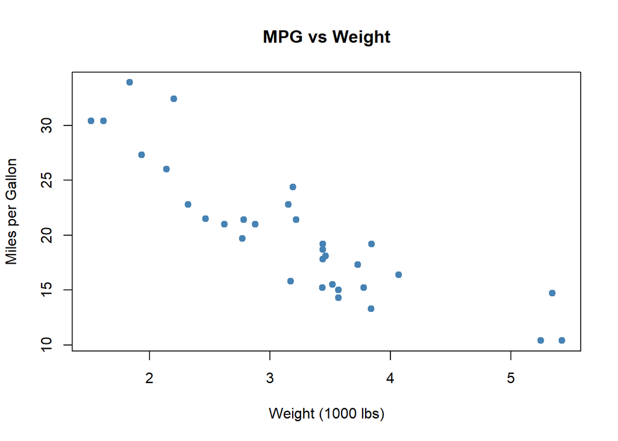

```r
plot(
  mtcars$wt, mtcars$mpg,
  main = "MPG vs Weight",
  xlab = "Weight (1000 lbs)",
  ylab = "Miles per Gallon",
  pch = 19,
  col = "steelblue"
)
```

The scatter plot shows a clear downward trend, suggesting a linear relationship.

## Linear Regression Model

We fit a simple linear regression model with mpg as the dependent variable and weight as the independent variable.

```r
model <- lm(mpg ~ wt, data = mtcars)
```

```r
summary(model)
```

```
##
## Call:
## lm(formula = mpg ~ wt, data = mtcars)
##
## Residuals:
##     Min      1Q  Median      3Q     Max
## -4.5432 -2.3647 -0.1252  1.4096  6.8727
##
## Coefficients:
##             Estimate Std. Error t value Pr(>|t|)
## (Intercept)  37.2851     1.8776  19.858  < 2e-16 ***
## wt           -5.3445     0.5591  -9.559 1.29e-10 ***
## ---
## Signif. codes:  0 '***' 0.001 '**' 0.01 '*' 0.05 '.' 0.1 ' ' 1
##
## Residual standard error: 3.046 on 30 degrees of freedom
## Multiple R-squared:  0.7528, Adjusted R-squared:  0.7446
## F-statistic: 91.38 on 1 and 30 DF,  p-value: 1.294e-10
```

## Interpretation

- Intercept (~37.29): Predicted mpg when weight is 0 (not realistic, but required for the equation).
- Slope (~−5.34): For every additional 1,000 lbs of weight, mpg decreases by about 5.34.
- This negative slope is statistically significant, meaning the relationship is unlikely due to random chance.

**Statistical Significance (p-values) Rule of Thumb:**

| p-value | Interpretation |
| --- | --- |
| < 0.001 | Very strong evidence (***) |
| < 0.01 | Strong evidence (**) |
| < 0.05 | Acceptable evidence (*) |
| > 0.05 | Not statistically significant |

- In this model, the p-value for weight is ≪ 0.001, providing strong evidence that weight affects mpg.
- Model Fit (R-squared) R² ≈ 0.75
- About 75% of the variation in mpg is explained by vehicle weight alone.
- The remaining 25% is due to other factors such as horsepower, engine size, and aerodynamics.

*Contextual Interpretation*

R² Range Meaning:

- 0.90–1.00 Excellent (rare in real data)
- 0.70–0.89 Good
- 0.40–0.69 Moderate
- < 0.40 Weak

In this case, 0.75 is strong, especially for a single-predictor model.

## Residual Diagnostics

We examine residuals to validate linear regression assumptions.

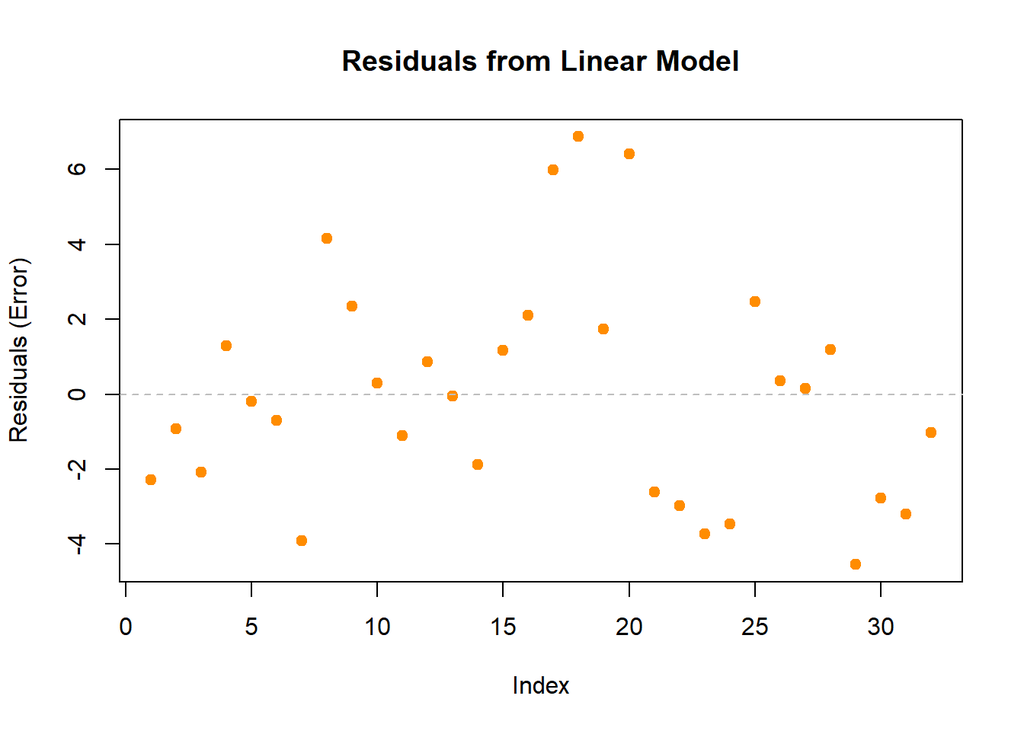

```r
plot(
  model$residuals,
  main = "Residuals from Linear Model",
  xlab = "Index",
  ylab = "Residuals (Error)",
  pch = 19,
  col = "darkorange"
)
abline(h = 0, lty = 2, col = "gray")
```

### Residual Interpretation

**A well-behaved residual plot should:**

- Be centered around 0
- Show no clear pattern
- Have roughly constant spread

In this plot, residuals are mostly centered around zero, though a slight wave pattern suggests a possible non-linear relationship.

**Common Residual Patterns (Reference)**

- Curve shape: Missing non-linearity → try polynomial terms
- Funnel shape: Heteroscedasticity → try transformations
- Outliers: Influential points → investigate or use robust methods
- Clusters: Missing categorical variable

**Key Findings**

- Weight is a strong, statistically significant predictor of mpg.
- The relationship is negative: heavier cars get lower fuel efficiency.
- The model explains ~75% of mpg variability using weight alone.

**Limitations**

- Only one predictor is used.
- Important variables (horsepower, cylinders) are omitted.

## Next Steps

- Fit a multiple regression: mpg ~ wt + hp
- Test non-linearity: add I(wt^2)
- Compare R² and residual behavior across models

## Week 1 Reflection

This exercise reinforced that linear regression is not just fitting a line, but validating assumptions using:

- **p-values**
- **R²**
- **residual diagnostics**

Understanding these components helps determine when a model is trustworthy and when more complexity is needed.